# Model

Lowson Li, R08323023

# 1 Load packages

```r
library(tidyverse)
library(knitr)
library(readr)
library(skimr)
library(lubridate)
library(stargazer)
library(ggthemes)
```

# 2 Model

In Model 1, I would like to explore the possible effect of the Elite account to the measurable of the businesses, especially the ratings.

## 2.1 Load data

[output not shown]

[output cut: 46 more lines]

## 2.2 Skim data

```r
skim(bru_full)
```

```
── Data Summary ────────────────────────
                           Values
Name                       bru_full
Number of rows             365417
Number of columns          39
_______________________
Column type frequency:
  character                12
  numeric                  27
________________________
Group variables            None

── Variable type: character ─────────────────────────────────────────────
   skim_variable n_missing complete_rate   min   max empty n_unique
 1 name                  0         1         1    32     0    19597
```

[output cut: 82 more lines]

## 2.3 Prepare data

(Since there may exist problems loading file with large amount of text, without-text version of the file is loaded.)

| name | review_count | yelping_since | useful | funny | cool | elite | fans | average_stars | compliment_hot | compliment_more | compliment_profile | compliment_cute | compliment_list | compliment_note | compliment_plain | compliment_cool | compliment_funny | compliment_writer | compliment_photos | user_id | review_id | r_stars | r_useful | r_funny | r_cool | text | date | business_id | b_name | … |
| --- | --- | --- | --- | --- | --- | --- | --- | --- | --- | --- | --- | --- | --- | --- | --- | --- | --- | --- | --- | --- | --- | --- | --- | --- | --- | --- | --- | --- | --- | --- |
| Taylor | 167 | 2011-12-28 02:26:04 | 1077 | 520 | 959 | 2016,2017,2018 | 47 | 4.24 | 37 | 2 | 3 | 1 | 0 | 16 | 33 | 59 | 59 | 39 | 14 | -nIVKbFxgBMHPVRJV2Djqw | FgrQNsn9SKvt-CXvH84R7g | 2 | 8 | 3 | 5 | Meh" is a pretty good description of the experience I had at Omoide Sushi & Noodle Bar today. I stopped in for a quick lunch and was encouraged that it was decently busy at 11:45. It's a fast casual s… | Phoenix | AZ | 85004 | … |
| Alejandro | 13 | 2013-10-21 23:41:29 | 16 | 7 | 5 | NA | 0 | 2.93 | 0 | 0 | 0 | 0 | 0 | 0 | 0 | 0 | 0 | 0 | 0 | a3qOhxLV7JW5Tjo-wxEc_g | 4_AOkZgb6QfyRwSOdPxW4g | 1 | 2 | 0 | 0 | Hello! Welcome!" "Good Morning" " Thank you"... No... None of that... Ok then I'll go somewhere else.. Seriously if you don't feel like working you should probably stay home with your 40 cats. Especia… | Phoenix | AZ | 85003 | … |
| Ginger | 36 | 2010-09-23 02:53:35 | 47 | 24 | 42 | NA | 13 | 4.30 | 25 | 2 | 2 | 4 | 0 | 19 | 44 | 73 | 73 | 4 | 26 | Tnl7W-J1JvlU1sDA3C5M3g | 8_bt-9fNY6gFiJlNxxL_qA | 4 | 0 | 0 | 0 | Gladly" I got invited to a brunch. "Gladly" I accepted and went. "Gladly" it was awesome. This is my first visit and don't know what to expect. Someone in our group ordered the Roasted Brussels Sprout… | Phoenix | AZ | 85016 | … |
| Raychel | 14 | 2016-06-19 04:59:41 | 1 | 0 | 1 | NA | 0 | 4.13 | 0 | 0 | 0 | 0 | 0 | 0 | 0 | 1 | 1 | 0 | 0 | GaO7Flu2XkBYU3jXAmph_Q | AkJA02OB-w0W3c23OkYoRQ | 5 | 0 | 0 | 0 | Open from 11:00 until the meat is gone" such an organic business model. Oren runs a friendly hospitable staff with high quality foods. The simple menu won't leave you wanting. Being on the end of the … | Phoenix | AZ | 85023 | … |
| Kim | 17 | 2012-03-26 16:27:02 | 30 | 9 | 5 | NA | 0 | 4.24 | 0 | 0 | 0 | 0 | 0 | 0 | 0 | 0 | 0 | 0 | 0 | ghMJr5bmVakHSs553-q6Fg | HQB8QTORcLUuiq1EM6tTsg | 1 | 1 | 1 | 0 | The Band tonight" One man doing a handy bandy job- was terrible!! whoever it was please go try your hardest at your day job!!!! yuk so terrible...... never going back.,2015-11-14 05:33:41,Qb1tuREKTsyV… | Phoenix | AZ | 85083 | … |
| Thomas | 9 | 2013-07-20 03:43:43 | 4 | 0 | 0 | NA | 0 | 1.78 | 0 | 0 | 0 | 0 | 0 | 0 | 0 | 0 | 0 | 0 | 0 | IcbtQZoOObZ9aBm2IlMBjA | pRyT5fV0FI0ZX82efjuzZQ | 1 | 0 | 0 | 0 | Private party"?? Again? Maybe you should just become a private caterer and forget about the rest of us. 2 times/2 strikes=gone.,2018-10-23 22:37:34,EV1jAj7NFNmNIqOnwZ4Acw,Copper Blues Rock Pub & Kitch… | Phoenix | AZ | 85003 | … |
| Mike | 40 | 2010-07-25 00:07:25 | 57 | 9 | 22 | NA | 5 | 3.17 | 0 | 0 | 0 | 0 | 0 | 0 | 0 | 1 | 1 | 0 | 0 | -grC9WQmDOUBvxS9dX_gXQ | 4CgfLjjC8-hI-d4slsM_4w | 4 | 0 | 0 | 0 | Great food and service. Would be good to have a kids menus to make it 5 stars.,2013-04-14 15:37:49,roz-ed8kvBF6fwKBPeJ49Q,Tutti Santi,"7575 N 16th St, Ste 5 | Phoenix | AZ | 85020 | … |

```r
bru_no_review_text <- read_csv("~/Downloads/bru_no_review_text.csv",
  col_types = cols(
    date = col_character(),
    elite = col_character(), is_open = col_logical(),
    yelping_since = col_character(),
    postal_code = col_character()
  )
)
```

```
Error: '~/Downloads/bru_no_review_text.csv' does not exist.
```

```r
# adjust time format and dummy for elite
bru_no_review_text <-
  bru_no_review_text %>%
  # sample_n(100) %>%
  mutate(has_elite = if_else(is.na(elite), 0, 1)) %>%
  mutate(days_diff = difftime(time1 = "2019-12-31", time2 = date(yelping_since), units = "days") %>% as.numeric()) %>%
  mutate(yelping_years = round(days_diff / 365, 3)) %>%
  select(-days_diff)
```

[output not shown]

| name | review_count | yelping_since | useful | funny | cool | elite | fans | average_stars | compliment_hot | compliment_more | compliment_profile | compliment_cute | compliment_list | compliment_note | compliment_plain | compliment_cool | compliment_funny | compliment_writer | compliment_photos | user_id | review_id | r_stars | r_useful | r_funny | r_cool | date | business_id | b_name | address | … |
| --- | --- | --- | --- | --- | --- | --- | --- | --- | --- | --- | --- | --- | --- | --- | --- | --- | --- | --- | --- | --- | --- | --- | --- | --- | --- | --- | --- | --- | --- | --- |

| name | review_count | yelping_since | useful | funny | cool | elite | fans | average_stars | compliment_hot | compliment_more | compliment_profile | compliment_cute | compliment_list | compliment_note | compliment_plain | compliment_cool | compliment_funny | compliment_writer | compliment_photos | user_id | review_id | r_stars | r_useful | r_funny | r_cool | date | business_id | b_name | address | … |
| --- | --- | --- | --- | --- | --- | --- | --- | --- | --- | --- | --- | --- | --- | --- | --- | --- | --- | --- | --- | --- | --- | --- | --- | --- | --- | --- | --- | --- | --- | --- |

## 2.4 Detect the cross-sectional effect of elite on business measuarables

### 2.4.1 Ratings

```r
# create business group statistics
bru_no_review_text %>%
  group_by(business_id) %>%
  mutate(elite_count = sum(has_elite),network_size = n_distinct(user_id)) %>%
  distinct(business_id,.keep_all = TRUE) %>%
  colnames()
```

```
 [1] "name"               "review_count"       "yelping_since"
 [4] "useful"             "funny"              "cool"
 [7] "elite"              "fans"               "average_stars"
[10] "compliment_hot"     "compliment_more"    "compliment_profile"
[13] "compliment_cute"    "compliment_list"    "compliment_note"
[16] "compliment_plain"   "compliment_cool"    "compliment_funny"
[19] "compliment_writer"  "compliment_photos"  "user_id"
[22] "review_id"          "r_stars"            "r_useful"
[25] "r_funny"            "r_cool"             "date"
[28] "business_id"        "b_name"             "address"
[31] "city"               "state"              "postal_code"
[34] "latitude"           "longitude"          "b_stars"
[37] "b_review_count"     "is_open"            "has_elite"
[40] "yelping_years"      "elite_count"        "network_size"
```

### 2.4.2 Simple linear regression

```r
# simple linear regression without much of business statistics
bru_no_review_text %>%
  group_by(business_id) %>%
  mutate(elite_count = sum(has_elite),network_size = n_distinct(user_id)) %>%
  mutate(real_stars = mean(r_stars,na.rm = TRUE)) %>%
  distinct(business_id,.keep_all = TRUE) %>%
  lm(formula = real_stars ~ elite_count + log(network_size)) %>%
  stargazer(type = "text")
```

[output not shown]

```
===============================================
                        Dependent variable:
                    ---------------------------
                            real_stars
-----------------------------------------------
elite_count                   0.001**
                             (0.0004)

log(network_size)            0.156***
                              (0.015)

Constant                     2.826***
                              (0.053)

-----------------------------------------------
Observations                   2,724
R2                             0.095
Adjusted R2                    0.094
Residual Std. Error      0.831 (df = 2721)
F Statistic          142.156*** (df = 2; 2721)
===============================================
Note:               *p<0.1; **p<0.05; ***p<0.01
```

In this simple linear regression, the number of Elite reviewers has slight effect on the overall ratings of the restaurants, conditional on the total review count and the size of the reviewers of the restaurants. Intuitively, Elite may be more “picky” so that the ratings they give is relatively low compare to the non Elite.

To test this assumption, we can run a simple regression compare the average ratings between Elite and non-Elite reviewers.

```r
bru_no_review_text %>%
  lm(data = ., formula = r_stars ~ has_elite  + review_count + yelping_years + useful + fans) %>%
  stargazer(type = "text")
```

[output not shown]

```
===============================================
                        Dependent variable:
                    ---------------------------
                              r_stars
-----------------------------------------------
has_elite                    0.166***
                              (0.006)

review_count                -0.0001***
                             (0.00001)

yelping_years                -0.004***
                              (0.001)

useful                      -0.00001***
                             (0.00000)

fans                         0.001***
                             (0.0001)

Constant                     3.851***
                              (0.007)

-----------------------------------------------
Observations                  365,431
R2                             0.002
Adjusted R2                    0.002
Residual Std. Error     1.368 (df = 365425)
F Statistic         147.022*** (df = 5; 365425)
===============================================
Note:               *p<0.1; **p<0.05; ***p<0.01
```

While the result suggest that control for basic characteristics of the reviewers, the Elite account seems to give higher stars to the business. This is contradict to the previous intuition that the Elite is more picky in terms of rating. On the other hand, if the Elite account has similar taste of the general public, the rating he/she gives would not have much differences. Possible **astroturfing** may exist.

Also, intuitively, when the network gets larger, the Elite account in the reviewer network of the businesses would get larger, though may not proportionally.

### 2.4.3 Elite count vs. nework size (tbd)

```
Removed 282 rows containing non-finite values (stat_bin).
```

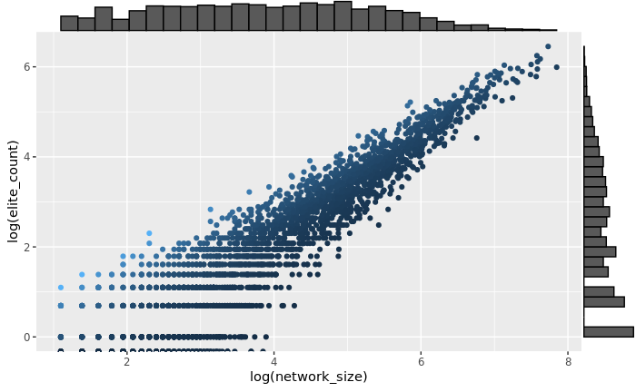

```r
ggMarginal(p, type = "histogram", size = 10)
```

The logged network size of the restaurants and logged number of Elite reviewers seems to be linearly correlated. While the density of the Elite account seems to present some variation.

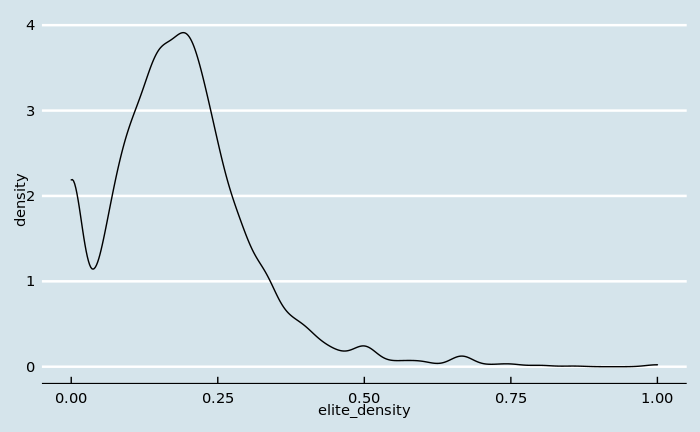

Notice that the distribution of Elite density in the network is right-skewed.

### 2.4.4 Use Elite density as independent variable

```r
bru_no_review_text %>%
  group_by(business_id) %>%
  mutate(elite_count = sum(has_elite), network_size = n_distinct(user_id)) %>%
  mutate(real_stars = mean(r_stars, na.rm = TRUE)) %>%
  mutate(elite_density = elite_count / network_size) %>%
  distinct(business_id, .keep_all = TRUE) %>%
  lm(formula = real_stars ~ elite_density) %>%
  stargazer(type = "text")
```

[output not shown]

```
===============================================
                        Dependent variable:
                    ---------------------------
                            real_stars
-----------------------------------------------
elite_density                0.648***
                              (0.133)

Constant                     3.338***
                              (0.030)

-----------------------------------------------
Observations                   2,724
R2                             0.009
Adjusted R2                    0.008
Residual Std. Error      0.869 (df = 2722)
F Statistic          23.761*** (df = 1; 2722)
===============================================
Note:               *p<0.1; **p<0.05; ***p<0.01
```

Notice that the average ratings of businesses has postive correlation with the Elite density.

The model problems so far:

1. The original model may suffer Omitted Variable Bias
2. The dependent variable here is limited, since the rating is larger than 1 and smaller than 5.
3. Astroturfing
4. The multicollinearity of the network size and the Elite count.

Use Censored Regression Models may be more appropriate.

### 2.4.5 Censored regression (Tobit)

```r
bru_no_review_text %>%
  group_by(business_id) %>%
  mutate(elite_count = sum(has_elite), network_size = n_distinct(user_id)) %>%
  mutate(real_stars = mean(r_stars, na.rm = TRUE)) %>%
  mutate(elite_density = elite_count / network_size) %>%
  distinct(business_id, .keep_all = TRUE) %>%
  censReg(formula = real_stars ~ elite_density, left = 1, right = 5) %>%
  # stargazer(type = "text")
  summary()
```

```
Call:
censReg(formula = real_stars ~ elite_density, left = 1, right = 5,
    data = .)

Observations:
         Total  Left-censored     Uncensored Right-censored
          2724             15           2667             42

Coefficients:
              Estimate Std. error t value  Pr(> t)
(Intercept)    3.34394    0.03035 110.174  < 2e-16 ***
elite_density  0.63490    0.13576   4.677 2.92e-06 ***
logSigma      -0.12233    0.01378  -8.877  < 2e-16 ***
---
Signif. codes:  0 ‘***’ 0.001 ‘**’ 0.01 ‘*’ 0.05 ‘.’ 0.1 ‘ ’ 1

Newton-Raphson maximisation, 4 iterations
Return code 1: gradient close to zero
Log-likelihood: -3538.702 on 3 Df
```

The result suggest that the density of the Elite in reviewer network of the restaurants has overall positive effect on ratings. Intuitively, this may result from the fact the Elite account post relatively more positive reviews for the business.

1. The result can be refine if the proportion of the sentiment is revealed.
2. More of the business characteristics should be included.

## 2.5 Extract sentiment

### 2.5.1 Estimate the cost of calling Google NL API

```r
bru_full %>%
  filter(!is.na(text)) %>%
  nrow()
```

```
[1] 365417
```

The official charging of sentiment analysis

```r
(365417)/1000
```

```
[1] 365.417
```

It’s about USD 360.

### 2.5.2 Test the validation of the Goolge NL API

```r
bru_full %>%
  select(user_id,has_elite,text) %>%
  filter(str_detect(user_id,"9gZ4pQHdK6v8xMLig6EEFA")) %>%
  sample_n(10) %>%
  select(text) %>% unlist()
```

[output not shown]

[output cut: 7 more lines]

## 2.6 Elite and rating outperformance

### 2.6.1 Business ratings distribution

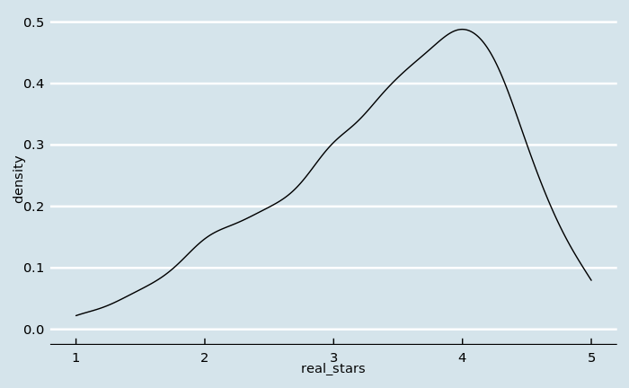

See the top 20% and bottom 20% ratings of business

```r
quantile(bru_temp$real_stars,probs = c(0.2,0.8))
```

```
     20%      80%
2.697228 4.222402
```

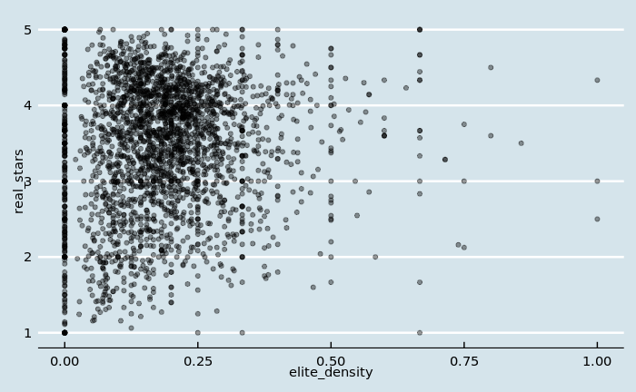

Notice that the Elite density of the reviewer network of the businesses is not directly correlated to the real ratings.

```r
stargazer(logit_1, logit_2, type = "text")
```

[output not shown]

```
==============================================
                      Dependent variable:
                  ----------------------------
                          outperformed
                       (1)            (2)
----------------------------------------------
elite_density         -0.317        -0.519
                     (0.388)        (0.414)

log(network_size)                  0.099***
                                    (0.033)

Constant            -1.328***      -1.682***
                     (0.085)        (0.148)

----------------------------------------------
Observations          2,724          2,724
Log Likelihood      -1,363.036    -1,358.532
Akaike Inf. Crit.   2,730.072      2,723.064
==============================================
Note:              *p<0.1; **p<0.05; ***p<0.01
```

Here I consider the network size as the **development status** of the restaurants. Which can be the proxy of the opening years, business in Yelp since, or the popularity in reviewers’ perspective.

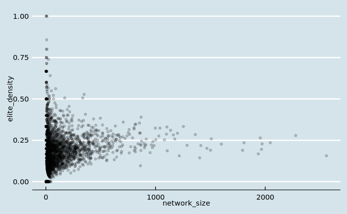

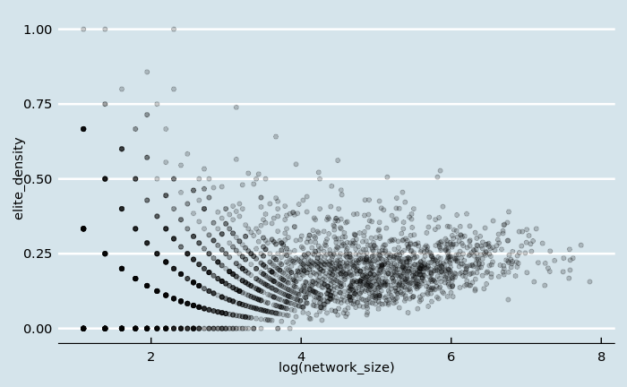

```r
lm(formula = elite_density ~ log(network_size),data = bru_temp) %>% summary()
```

```
Call:
lm(formula = elite_density ~ log(network_size), data = bru_temp)

Residuals:
     Min       1Q   Median       3Q      Max
-0.18517 -0.07946 -0.01593  0.05330  0.85563

Coefficients:
                  Estimate Std. Error t value Pr(>|t|)
(Intercept)       0.144374   0.006751  21.384  < 2e-16 ***
log(network_size) 0.010597   0.001628   6.509 8.97e-11 ***
---
Signif. codes:  0 ‘***’ 0.001 ‘**’ 0.01 ‘*’ 0.05 ‘.’ 0.1 ‘ ’ 1

Residual standard error: 0.1253 on 2724 degrees of freedom
Multiple R-squared:  0.01532,   Adjusted R-squared:  0.01495
F-statistic: 42.37 on 1 and 2724 DF,  p-value: 8.968e-11
```

Though may suffer from OVB, but intuitively there exists the possibility that the more popular (in terms of more reviews) restaurants will attract more Elite to leave their comment. This is somehow implying the hypothetical phenomenon called **preferential attachment**.

Notice that none of these regression result suggest that the Elite density of the reviewer network of the restaurants has strong correlation on business overall reviews! Consider that in the real world, the Elite account has small amount. While it could potentially affect the ratings formation of others. Maybe we can try to recover the baseline ratings without Elite account’s effect, and compare how this would be different after the first Elite had joined.

## 2.7 Potential causal effect

```r
bru_no_review_text %>%
  colnames()
```

```
 [1] "name"               "review_count"       "yelping_since"
 [4] "useful"             "funny"              "cool"
 [7] "elite"              "fans"               "average_stars"
[10] "compliment_hot"     "compliment_more"    "compliment_profile"
[13] "compliment_cute"    "compliment_list"    "compliment_note"
[16] "compliment_plain"   "compliment_cool"    "compliment_funny"
[19] "compliment_writer"  "compliment_photos"  "user_id"
[22] "review_id"          "r_stars"            "r_useful"
[25] "r_funny"            "r_cool"             "date"
[28] "business_id"        "b_name"             "address"
[31] "city"               "state"              "postal_code"
[34] "latitude"           "longitude"          "b_stars"
[37] "b_review_count"     "is_open"            "has_elite"
[40] "yelping_years"
```

### 2.7.1 Recover the unbiased ratings

```r
bru_no_review_text %>%
  select(date) %>%
  mutate(date = lubridate::parse_date_time(date,"ymd HMS")) %>%
  glimpse()
```

```
Rows: 365,431
Columns: 1
$ date <dttm> 2013-06-14 05:57:33, 2017-05-15 03:27:26, 2012-10-09 20:44:10, 2…
```

| business_id | date | user_id | has_elite |
| --- | --- | --- | --- |
| _-OJ4-bPGyKQ9Hcc5JeSqw | 2017-09-29 22:53:51 | 0s9CbvHm-kuhZzre9Oum5A | 0 |
| _-OJ4-bPGyKQ9Hcc5JeSqw | 2017-09-29 23:40:00 | Y9iSNkeEgJEragsFBW42oA | 0 |
| _-OJ4-bPGyKQ9Hcc5JeSqw | 2017-09-30 01:18:37 | qioIQ9ENhzAoAOMzw4_F-g | 0 |
| _-OJ4-bPGyKQ9Hcc5JeSqw | 2017-11-06 03:52:39 | 20svwt6_PknWMO7Ph9p4mw | 0 |
| _-OJ4-bPGyKQ9Hcc5JeSqw | 2018-04-16 17:08:02 | OvYN86BmZyP87SaTO7mHkQ | 0 |
| _-OJ4-bPGyKQ9Hcc5JeSqw | 2018-07-06 22:48:24 | 5-bhHg-sX1eFXUuQ7HqjyQ | 0 |
| _-OJ4-bPGyKQ9Hcc5JeSqw | 2018-09-29 01:37:29 | j4KaTVeOxUyIRjdRO3vl0Q | 1 |
| _1dS8bRrhN8hoCn58vmoHg | 2017-10-27 16:25:19 | StvVguoRgqCDOvg_X9OZIA | 0 |
| _1dS8bRrhN8hoCn58vmoHg | 2017-11-04 02:54:22 | KIu3u7tFfJzFIEfXM9m0Xw | 0 |
| _1dS8bRrhN8hoCn58vmoHg | 2017-12-21 18:53:22 | diYbASjeqV4CxkoyeBeBGw | 1 |

| review_year | elite | effective_elite |
| --- | --- | --- |
| 2017 | 2015,2016,2017,2018 | 1 |
| 2016 | 2015,2016,2017,2018 | 1 |
| 2018 | 2011,2012,2013,2014,2015,2016,2017,2018 | 1 |
| 2011 | 2010,2011,2012 | 1 |
| 2011 | 2010,2011,2012 | 1 |
| 2011 | 2010,2011,2012 | 1 |
| 2017 | 2012,2013,2014,2015,2016,2017,2018 | 1 |
| 2015 | 2012,2013,2014,2015,2016,2017,2018 | 1 |
| 2013 | 2012,2013,2014,2015,2016,2017,2018 | 1 |
| 2018 | 2013,2014,2015,2016,2017,2018 | 1 |

| business_id | review_id | effective_elite |
| --- | --- | --- |
| pSQFynH1VxkfSmehRXlZWw | NB4E9LQKJxo0SPnWV6taCQ | 0 |
| v9u0NgjA4iQeKGevFnYSCA | Xv5THdeU3h_E-9v3jtFLtQ | 0 |
| _DPJ_PHJnXsuhYhsgBA0Xw | aRzFeBf-hUCr4dkNQl-P3g | 0 |
| pSQFynH1VxkfSmehRXlZWw | Xb80if20vcCikbFqXJqjOg | 0 |
| BVYvfJiVcQTl9B311z518w | Nq6IDrsjcwAZTB0SPp7K9A | 0 |
| 50NTSGbZ3pN5643_K1IReA | yrySUMtAqwKUQ6eqLWX5PA | 0 |
| OgJ0KxwJcJ9R5bUK0ixCbg | h5YC1qYa9JD7RPorRHh_dQ | 0 |
| eS29S_06lvsDW04wVrIVxg | OybsTOFlklnoFl8ZwRa_AQ | 0 |
| pSQFynH1VxkfSmehRXlZWw | TZKnNt9_-t7K7uzk5V-Vcw | 0 |
| dc6sPg9kNliz_Cy2yX19tw | lLL4eLHwhQHZrBn9qq26Tw | 0 |

[output cut: 90 more lines]

| name | review_count | yelping_since | useful | funny | cool | elite | fans | average_stars | compliment_hot | compliment_more | compliment_profile | compliment_cute | compliment_list | compliment_note | compliment_plain | compliment_cool | compliment_funny | compliment_writer | compliment_photos | user_id | review_id | r_stars | r_useful | r_funny | r_cool | date | business_id | b_name | address | … |
| --- | --- | --- | --- | --- | --- | --- | --- | --- | --- | --- | --- | --- | --- | --- | --- | --- | --- | --- | --- | --- | --- | --- | --- | --- | --- | --- | --- | --- | --- | --- |
| Bridget | 113 | 2013-06-30 03:56:47 | 210 | 70 | 73 | 2014,2015,2016,2017 | 12 | 3.73 | 2 | 0 | 0 | 1 | 0 | 3 | 6 | 6 | 6 | 4 | 3 | Y-jnqLk05gHJ2ZJIzmoHOg | GIByOecDhrMXMaIOfvkZ0A | 5 | 0 | 0 | 0 | 2014-01-27 05:27:29 | S6TMBqrsi4PLRFoQFPScjQ | Green New American Vegetarian | 2022 N 7th St | … |

| avg_b_stars |
| --- |
| 3.679101 |

```r
# bru_temp <-
  bru_no_review_text %>%
  mutate(review_year = str_extract(date, "^\\d{4}")) %>%
  mutate(effective_elite = if_else(is.na(elite), 0L, str_detect(elite, review_year) %>% as.integer())) %>%
  group_by(business_id) %>%
  arrange(business_id, date) %>%
  mutate(group_order = row_number()) %>%
  mutate(appeared_elite = cumsum(effective_elite)) %>%
  mutate(evolved_network = if_else(appeared_elite < 1, 0, 1)) %>%
  mutate(b_has_elite = if_else(sum(appeared_elite)==0,0,1)) %>%
  filter(b_has_elite == 0) %>%
  distinct(business_id, .keep_all = TRUE) %>%
  nrow()
```

```
[1] 368
```

There are 368 restaurants has never comment by the Elite account.

Let’s see the overall performance of the restaurants:

| b_has_elite | avg_stars |
| --- | --- |
| 0 | 3.216033 |
| 1 | 3.497241 |

If the network has ever commented by Elite, overall, the restaurants’ rating will increased 0.28 star, approx. 8.7% increased.

```r
stargazer(cens1, cens2, cens3, cens4,type = "text")
```

[output not shown]

```
===============================================================
                                Dependent variable:
                    -------------------------------------------
                               real_stars             b_stars
                       (1)        (2)        (3)        (4)
---------------------------------------------------------------
elite_density        0.635***   0.691***   0.512***   0.522***
                     (0.136)    (0.156)    (0.149)    (0.156)

log(network_size)                          0.174***   0.172***
                                           (0.011)    (0.012)

logSigma            -0.122***  -0.122***  -0.168***  -0.126***
                     (0.014)    (0.014)    (0.014)    (0.014)

Constant             3.344***   3.363***   2.711***   2.729***
                     (0.030)    (0.028)    (0.049)    (0.051)

---------------------------------------------------------------
Observations          2,724      2,724      2,724      2,724
Log Likelihood      -3,538.702 -3,539.809 -3,421.275 -3,541.574
Akaike Inf. Crit.   7,083.404  7,085.618  6,850.550  7,091.148
Bayesian Inf. Crit. 7,101.134  7,103.348  6,874.189  7,114.788
===============================================================
Note:                               *p<0.1; **p<0.05; ***p<0.01
```

Here we can find that the models with the **real stars** as dependent variable have lower AIC and BIC. Real stars is the ratings collected by the given ratings in each review, instead of directly inherit from the data set.

Distribution of independent variables

```r
bru_temp %>%
  ungroup() %>%
  mutate(log_network_size = log(network_size)) %>%
  select(log_network_size, elite_density) %>%
  skimr::skim()
```

```
── Data Summary ────────────────────────
                           Values
Name                       Piped data
Number of rows             2724
Number of columns          2
_______________________
Column type frequency:
  numeric                  2
________________________
Group variables            None

── Variable type: numeric ───────────────────────────────────────────────────────────────────────────────
  skim_variable    n_missing complete_rate  mean    sd    p0    p25   p50   p75  p100 hist
1 log_network_size         0             1 3.88  1.47   1.10 2.71   3.85  5.03   7.85 ▅▇▇▅▁
2 elite_density            0             1 0.142 0.109  0    0.0714 0.131 0.192  1    ▇▂▁▁▁
```

The marginal effect of the third model, mean of the independent variable

```r
margEff(cens3) %>% summary()
```

```
                  Marg. Eff. Std. Error t value  Pr(>|t|)
elite_density        0.49330    0.14377  3.4312 0.0006099 ***
log(network_size)    0.16813    0.01067 15.7572 < 2.2e-16 ***
---
Signif. codes:  0 ‘***’ 0.001 ‘**’ 0.01 ‘*’ 0.05 ‘.’ 0.1 ‘ ’ 1
```

The marginal effect of the third model, 75 percentile of the independent variable

```r
margEff(cens3, xValues = c(1,0.192,5.03)) %>% summary()
```

```
                  Marg. Eff. Std. Error t value  Pr(>|t|)
elite_density       0.480626   0.139631  3.4421 0.0005859 ***
log(network_size)   0.163811   0.010115 16.1949 < 2.2e-16 ***
---
Signif. codes:  0 ‘***’ 0.001 ‘**’ 0.01 ‘*’ 0.05 ‘.’ 0.1 ‘ ’ 1
```

We can show that there’s not distribution difference between theses 2 ratings.

```r
# Wilcoxon signed rank test.
wilcox.test(x = bru_temp$real_stars,y=bru_temp$b_stars)
```

```
    Wilcoxon rank sum test with continuity correction

data:  bru_temp$real_stars and bru_temp$b_stars
W = 3703162, p-value = 0.9048
alternative hypothesis: true location shift is not equal to 0
```

The distribution of the ratings have no significant differences.

### 2.7.2 Timeline of reviewers

Pick the 75th percentile size of network

| business_id |
| --- |
| Tp07u-0AOFRfQhtNpAXaQA |

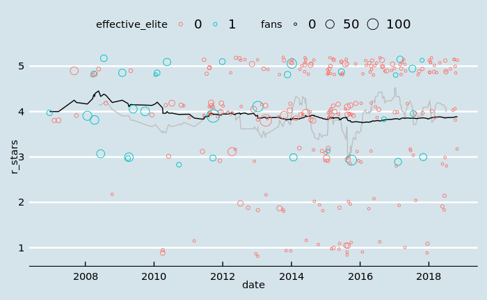

Most of time, it’s unclear that what Elite has any effect on making any visible impact on the later ratings by normal users. While sometimes the story could be interesting.

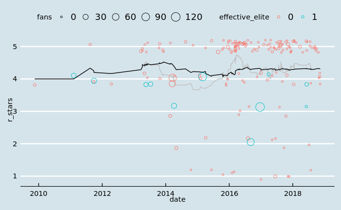

Take this restaurant for example, when the early Elites rated at 4 or even fewer, there would be bunch of non-Elite users rated 5. While in the same year, the Elites gave relatively low ratings.

Is Elite more picky so that they gave relatively low ratings? Or is Elite is not picky, but the normal users gave the ratings more generous?

Is the ratings could possible be manipulated by the restaurants?

When we talking about someone is picky, it means that **from the his/her comment history, the probability of giving high compliment is relatively low, comparing to others**

### 2.7.3 Is Elite more picky?

```r
bru_temp <-
  bru_no_review_text %>%
  left_join(avg_ratings, by = "user_id") %>%
  group_by(business_id) %>%
  mutate(review_year = str_extract(date, "^\\d{4}")) %>%
  mutate(effective_elite = if_else(is.na(elite), 0L, str_detect(elite, review_year) %>% as.integer())) %>%
  ungroup()
```

[output not shown]

```r
bru_temp %>%
  distinct(user_id, .keep_all = TRUE) %>%
  select(Average_stars) %>%
  skimr::skim()
```

```
── Data Summary ────────────────────────
                           Values
Name                       Piped data
Number of rows             144001
Number of columns          1
_______________________
Column type frequency:
  numeric                  1
________________________
Group variables            None

── Variable type: numeric ──────────────────────────────────────────────────────────────────────────────────────────────────────
  skim_variable n_missing complete_rate  mean    sd    p0   p25   p50   p75  p100 hist
1 Average_stars         0             1  3.79  1.12     1  3.17     4  4.79     5 ▂▂▃▆▇
```

Does the average personal historical ratings have the same distribution?

```r
wilcox.test(x = bru_temp_star$average_stars_AZ,y = bru_temp_star$Average_stars,paired = TRUE)
```

```
    Wilcoxon signed rank test with continuity correction

data:  bru_temp_star$average_stars_AZ and bru_temp_star$Average_stars
V = 2140660336, p-value < 2.2e-16
alternative hypothesis: true location shift is not equal to 0
```

By the Wilcoxon signed rank test, we find that the average ratings given by the user for AZ restaurants is different from their own historical ratings.

```r
wilcox.test(x = bru_temp_star$average_stars_AZ,y = bru_temp_star$Average_stars,paired = TRUE,alternative = "greater")
```

```
    Wilcoxon signed rank test with continuity correction

data:  bru_temp_star$average_stars_AZ and bru_temp_star$Average_stars
V = 2140660336, p-value < 2.2e-16
alternative hypothesis: true location shift is greater than 0
```

We also find that the PX,AZ restaurants got higher ratings compares to the average historical rating of the users. But this may also implies that the AZ restaurants raters prefer PX,AZ than other city.

```r
stargazer(lm_low, lm_mid, lm_high, logit_low, logit_mid, logit_high, type = "text")
```

[output not shown]

```
======================================================================================================================
                                                                  Dependent variable:
                                  ------------------------------------------------------------------------------------
                                  lower_ratings  mid_ratings  higher_ratings lower_ratings mid_ratings  higher_ratings
                                       OLS           OLS           OLS         logistic      logistic      logistic
                                       (1)           (2)           (3)            (4)          (5)           (6)
----------------------------------------------------------------------------------------------------------------------
effective_elite                     -0.123***     0.266***      -0.143***      -1.004***     1.107***     -0.599***
                                     (0.002)       (0.002)       (0.002)        (0.015)      (0.009)       (0.010)

Constant                            0.213***      0.310***       0.477***      -1.307***    -0.800***     -0.092***
                                     (0.001)       (0.001)       (0.001)        (0.004)      (0.004)       (0.004)

----------------------------------------------------------------------------------------------------------------------
Observations                         365,431       365,431       365,431        365,431      365,431       365,431
R2                                    0.013         0.041         0.011
Adjusted R2                           0.013         0.041         0.011
Log Likelihood                                                               -177,112.800  -229,747.000  -249,800.100
Akaike Inf. Crit.                                                             354,229.600  459,497.900   499,604.300
Residual Std. Error (df = 365429)     0.393         0.468         0.495
F Statistic (df = 1; 365429)      4,651.527***  15,439.150***  3,991.601***
======================================================================================================================
Note:                                                                                      *p<0.1; **p<0.05; ***p<0.01
```

Overall, it is less likely that the Elite would give lower ratings than non-Elite reviewers.

But does that means Elite rate more generously than non-Elite?

Seems not,it is less likely that the Elite would give higher ratings than non-Elite reviewers.

While interestingly, the Elite account seems to be more conservative in ratings. It is more likely that the Elite would give normal ratings, which means we can expect the density of ratings is more concentrated for Elite.

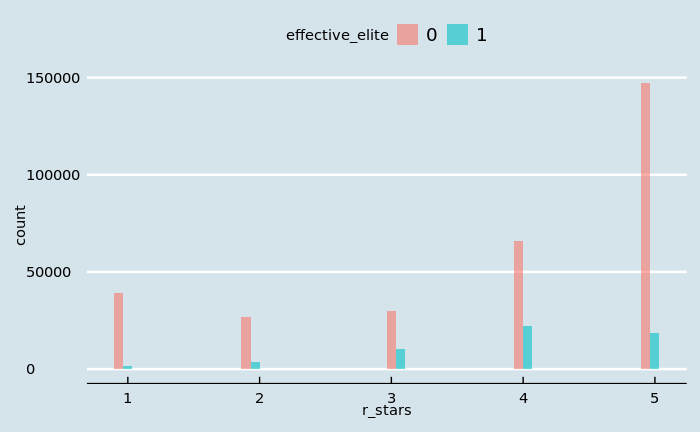

### 2.7.4 Rating behavior

```r
rating_behavior <-
  bru_temp %>%
  group_by(business_id, effective_elite) %>%
  summarise(avg_ratings = mean(r_stars, na.rm = TRUE)) %>%
  ungroup() %>%
  arrange(business_id, effective_elite) %>%
  mutate(effective_elite = if_else(effective_elite == 1, "Elite", "Normal")) %>%
  pivot_wider(names_from = effective_elite, values_from = avg_ratings)
```

[output not shown]

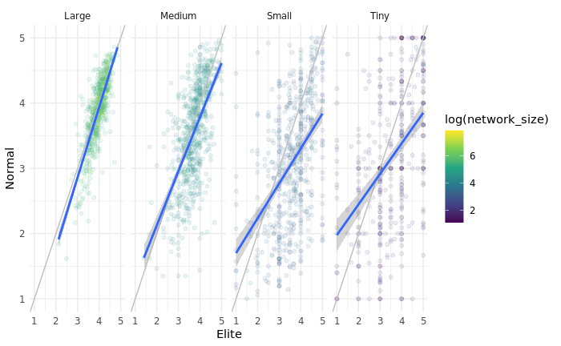

Tough we are using sampled data, but if we consider this is the sample snapshot of the account identity differences in ratings between Elite and Normal reviewers across the difference size of the businesses review network, this will provide some interesting observation:

What?

1. Identity difference in ratings is getting smaller when the network size getting larger.
2. Variance in distribution is relatively large when the network size is small.

Is it true?

```r
stargazer(rb1, rb2, rb3, rb4, type = "text")
```

[output not shown]

```
===============================================================
                                Dependent variable:
                    -------------------------------------------
                                      Normal
                       (1)        (2)        (3)        (4)
---------------------------------------------------------------
Elite                0.685***   0.619***   0.684***   0.614***
                     (0.021)    (0.021)    (0.021)    (0.021)

log(network_size)               0.149***              0.159***
                                (0.011)               (0.011)

elite_density                               0.053     0.570***
                                           (0.160)    (0.158)

logSigma            -0.298***  -0.337***  -0.298***  -0.340***
                     (0.015)    (0.015)    (0.015)    (0.015)

Constant             0.922***   0.543***   0.914***   0.433***
                     (0.079)    (0.081)    (0.082)    (0.086)

---------------------------------------------------------------
Observations          2,355      2,355      2,355      2,355
Log Likelihood      -2,646.424 -2,560.741 -2,646.368 -2,554.267
Akaike Inf. Crit.   5,298.848  5,129.482  5,300.737  5,118.534
Bayesian Inf. Crit. 5,316.141  5,152.539  5,323.794  5,147.355
===============================================================
Note:                               *p<0.1; **p<0.05; ***p<0.01
```

## 2.8 Previous elite vs. current restaurant status